# Getting Started with Bayesian Statistics

### Do not repeat yourself

The main rule for making Stan programs go fast is *don’t repeat yourself*. If there is a computation, don’t do that computation again, save the result in a local variable and reuse. For example, don’t do this:

```stan
for (n in 1:N) {
  y[n] ~ normal(alpha + beta * x[n], exp(log_sigma));
}
```

The problem here is that `exp(log_sigma)` gets computed `N` times. This uses more memory, as Stan records every operation with links to its operands during. It is also slow, with `N - 1` redundant applications of exponentiation in the forward pass and and multiply/adds for the chain rule in the backward pass. Instead, the code should be refactored to compute the exponentiation of `log_sigma` once, assign it to a local variable, and re-use it in the loop.

```stan
real sigma = exp(log_sigma);
for (n in 1:N) {
  y[n] ~ normal(alpha + beta * x[n], sigma);
}
```

### Avoid automatic differentiation if possible

If you have a constant that’s being defined, define it in the transformed data block. That way it only gets evaluated once. For example, don’t do the following, as it repeatedly allocates and fills a $K$-vector and then applies useless automatic differentiation steps in the reverse pass.

```stan
data {
  real<lower=0> alpha;
}
model {
  vector[K] alpha_v = rep_vector(alpha, K);
  theta ~ dirichlet(alpha_v);
}
```

Instead, define the constant in the transformed data block and then reuse it in the model block, as follows.

```stan
transformed data {
  vector<lower=0>[K] alphas = rep_vector(alpha, K);
}
model {
  theta ~ dirichlet(alphas);
}
```

The other way to get rid of autodiff is to move posterior predictions into the generated quantities block. In general, if it’s possible to move a variable to the generated quantities block, it should be moved. For example, we might be tempted do posterior predictive simulation as follows.

```stan
parameters {
  real alpha, beta;
  real<lower=0> sigma;
  vector[M_tilde] y_tilde;
}
model {
  y ~ normal(alpha + beta * x, sigma);
  y_tilde ~ normal(alpha + beta * x_tilde, sigma);
}
```

This is correct and will provide the right answer, but it is computationally and statistically inefficient. It’s computationally inefficient because Hamiltonian Monte Carlo is more expensive than random variate generation. It’s also statistically inefficient because it will typically produce correlated draws rather than independent draws, leading to a lower effective sample size. In situations like this, we can move `y_tilde` down to generated quantities because it’s conditionally independent of the data given `mu` and `sigma.`

```stan
parameters {
  real alpha, beta;
  real<lower=0> sigma;
}
model {
  y ~ normal(alpha + beta * x, sigma);
}
generated quantities {
  array[M_tilde] y_tilde = normal_rng(alpha + beta * x_tilde, sigma);
}
```

Vectorized `_rng` functions return arrays; if we really need a vector for `y_tilde` for some reason, we can convert with `to_vector().`

### Do not use diagonal multivariate normal

Instead of

```stan
y ~ multi_normal(mu, diag_matrix(sigma));
```

which creates a matrix then factors to compute its inverse and determinant, we can use the vectorized form of the univariate normal,

```stan
y ~ normal(mu, sigma);
```

The result is the same up to a constant.

### Memory locality, copying, and storage order

Accessing a row or column of a matrix requires allocating memory and copying. Memory pressure is one of the biggest constraints in modern code and relieving it is one of the best things to do to make code go faster.

Matrices are organized in column-major order in memory, whereas arrays are row major. That means that the columns of a matrix are stored together in memory, and therefore slicing out a column `Sigma[1:M, n]` is relatively efficient for large `M`, but slicing out a row using `Sigma[m, 1:N]` will be inefficient if `M` is large.

If you need to access vectors one by one but you do not need matrix operations, use an array of vectors in either order:

```stan
matrix[M, N] alpha;
array[M] row_vector[N] alpha_arr;
array[N] vector[M] alpha_t_arr;  // transposed
```

Accessing elements of an array does not require any copying.

Overall, copying and rearranging data structures is not very expensive in Stan. Loops are very fast, and rearranging doesn’t add anything to the expression graph for automatic differentiation.

### Vectorize non-linear operations over parameters

Even though loops are very fast in Stan, every expression involving parameters leads to nodes and edges being added to the expression graph. The usual suspect is sampling in a loop, as follows.

```stan
for (n in 1:N) {
  y[n] ~ normal(alpha + beta * x[n], sigma);
}
```

Written this way, Stan isn’t smart enough to realize it can compute `log(sigma)` once and re-use. It will also build a huge number of expression graph edges from the log density of to `alpha` and `beta`, one for each `y[n].` The same contribution to the log density can be executed much faster with vectorized code such as the following.

```stan
y ~ normal(alpha + beta * x, sigma);
```

The speed from vectorization is not because loops are slow, it’s because doing autodiff in a loop leads to a much larger expression graph and hence much more work when updating the chain rule. The vectorized form has a single output variable for the log density with three edges leading to `alpha`, `beta`, and `sigma.` It will also be clever enough to calculate `log(sigma)` once and reuse it. This advantage is even bigger for distributions like multivariate normal that require expensive internal determinant calculations.

## 13.2 Statistical efficiency

By far the best solution for making Stan programs go faster is to improve the statistical efficiency of the model.

### Identifiability

The first thing to consider is *identifiability*. A likelihood $p(y \mid \theta)$ is *identifiable* if distinct parameters lead to distinct likelihoods, or in symbols, if $\theta \neq \theta'$ implies $p(y \mid \theta) \neq p(y \mid \theta')$. The other way around, a likelihood is not identifiable if there exist $\theta \neq \theta'$ such that $p(y \mid \theta) = p(y \mid \theta').$

The classic *Bradley-Terry model* for inferring quality based on pairwise comparisons has a non-identifiable likelihood. Let’s consider an application to sports team ranking (it was originally applied to consumer products). Each team $j$ has an ability ranking $\alpha_j$. The log odds of team $j$ defeating team $k$ is modeled as $\alpha_j - \alpha_k$. The observations are of the results of games $n$ between team $A_n$ and $B_n$ (the notation is meant to be suggestive of the original application to A/B testing). This defines the likelihood
$$p(y_n \mid \alpha) = \textrm{bernoulli}(\textrm{logit}^{-1}(\alpha_{A_n} - \alpha_{B_n}).$$
In Stan, this likelihood can be coded as

```stan
model {
  y ~ bernoulli_logit(alpha[A] - alpha[B]);
}
```

where the vectorized sampling statement unfolds to the following equivalent, but less efficient, form.

```stan
  for (n in 1:N) {
    y[n] ~ bernoulli_logit(alpha[A[n]] - alpha[B[n]]);
  }
```

The model is clearly non-identifiable because
$$p(y_n \mid \alpha) = p(y_n \mid \alpha + c).$$

To get around this problem, we can do three things. The first two involve reducing the number of free parameters and the third involves soft identification through a prior. First, we can pin one of the values $\alpha$, traditionally by setting $\alpha_1 = 0$. This reduces the number of free parameters by one, as is reflected in the Stan parameterization.

```stan
parameters {
  vector[J - 1] alpha_rest;
}
transformed parameters {
  vector[J] alpha = append_row(0, alpha_rest);
}
```

We can then work with `alpha` directly. In the second approach, we can enforce the constraint $\textrm{sum}(\alpha) = 0$. This also reduces the number of free parameters by one and is coded in a similar way, only with a different transform.

```stan
transformed parameters {
  vector[J] alpha = append_row(-sum(alpha_rest), alpha_rest);
}
```

On the plus side, this approach is symmetric. On the downside, it is not generative in that it is not clear how to add a new player $J + 1$.

The third way to make a Bayesian model identifiable is to add a prior. For example, we can do this,

```stan
model {
  alpha ~ normal(0, 3);
}
```

This provides a kind of *soft identification* in the posterior, where values of `alpha` near 0 have higher posterior density. The third approach is overparameterized but has a pleasing symmetry and generalizability to new players.

### Adaptation and preconditioning

The *condition number* of a positive-definite matrix is the ratio of its largest eigenvalue to its smallest. For a density, we can consider the negative inverse Hessian of its log density at a point. For a multivariate normal distribution, the negative inverse Hessian is its covariance at every point. That is, a normal distribution has *constant curvature*.

The larger the condition number, the harder it is to sample from a model, because multiple steps at the scale of the smallest eigenvalue are required to take a step in the direction of the largest eigenvalue. The first-order gradient-based approximation that Hamiltonian Monte Carlo uses can also fail due to high curvature; when the step is too large, the result will be *divergent* Hamiltonian trajectories (i.e., ones that do not preserve the Hamiltonian).

When the inverse Hessian is not positive definite, the density is not convex, which can present an even greater challenge to sampling than poor conditioning. If the inverse Hessian is positive definite and relatively constant over the posterior, we can correct for non-unit conditioning by *preconditioning*, which can rotate and scale a density until it looks more like a standard normal. In fact, given a multivariate normal it does just that—rotates and scales back to a standard normal.

Stan begins adaptation in a state that assumes the posterior is standard normal, which is (a) centered at the origin, (b) independent in dimension, and (c) unit scale. The closer a posterior is to standard normal, the easier it will be for Stan to adapt and to sample.

During adaptation, Stan estimates the posterior (co)variance to use for preconditioning. If the posterior Hessian is constant, the covariance will be equal to the negative inverse Hessian everywhere.

With its default settings, Stan preconditions by scaling each of the parameters as close to unit scale as it can manage. Under this scheme, in $D$ dimensions, the adapted metric requires $\mathcal{O}(D)$ storage and each leapfrog step (the most inner loop in Stan) requires $\mathcal{O}(D)$ time. By selecting a dense metric, Stan will also adapt to a fixed curvature (i.e., one that does not vary over the posterior). This requires $\mathcal{O}(D^2)$ storage, several $\mathcal{O}(D^3)$ costs to Cholesky factor, and then requires $\mathcal{O}(D^2)$ time per leapfrog step to evaluate.

### Reparameterization

We can often reparameterize models to make them easier to sample. The standard example is reparameterizing a varying effect to use a *non-centered parameterization*. The centered parameterization is

```stan
parameters {
  real<lower=0> sigma;
  vector[N] alpha;
}
model {
  sigma ~ lognormal(0, 1.5);
  alpha ~ normal(0, sigma);
}
```

This model induces a strong dependence between `sigma` and `alpha.` When `sigma` is small, `alpha` must be small, and when `sigma` is large, `alpha` will vary over a wide range. This varying curvature (high curvature for low `sigma`, very flat expanses for high `sigma`) is very challenging for MCMC sampling.

We can overcome the difficulty in this parameterization by non-centering, which we can code explicitly as follows.

```stan
parameters {
  real<lower=0> sigma;
  vector[N] alpha_std;
}
transformed parameters {
  alpha = sigma * alpha_std;
}
model {
  sigma ~ lognormal(0, 1.5);
  alpha_std ~ normal(0, 1);
}
```

We now have an independent standard normal distribution on `alpha_std`, not on `alpha.` It induces the correct distribution on the transformed parameter `alpha`, so that `alpha` has a `normal(0, sigma)` distribution. While this correction is only in the prior, if there is not a lot of data for each `n`, the posterior will be similar.

We can code the same model as above using an affine variable transform to rescale `alpha` with `sigma`.

```stan
parameters {
  real<lower=0> sigma;
  vector<multiplier=sigma>[N] alpha;  // non-centering
}
model {
  sigma ~ lognormal(0, 1.5)
  alpha ~ normal(0, sigma);
}
```

### Priors for speed and knowledge

Often we are tempted to use vague or overdispersed priors. When this gets too extreme, it can cause computational difficulties navigating flat expanses of probability space. And we will have statistical difficulties from the prior pulling most of the probability mass away from the natural posterior.

If you have used vague priors to avoid thinking too hard and computation is going awry, you might consider adding priors with a bit more information. It’s often possible to impose *weakly informative* priors that only determine the scale of a variable, which is often known. For example if we think a value $\alpha$ is going to have a value in the single digits, we can use a prior like

```stan
alpha ~ normal(0, 5);
```

that puts approximately 95% of the probability mass in the region $(-10, 10)$.

We do not recommend interval constraints other than for naturally constrained parameters (e.g., probabilities fall in $[0, 1]$ and concentrations in $[0, \infty)$). The reason we do not want to use

```stan
alpha ~ uniform(-10, 10);
```

is that if the data is consistent with `alpha` near the boundary (-10 or 10), then probability mass gets bunched up and posterior means get pushed away from the boundary. For example, consider the following Stan program.

```
stan/interval-censor.stan
```

```stan
data {
  int<lower=0> B;
  int<lower=0> N;
  vector[N] y;
}
parameters {
  real<lower=-B, upper=B> mu;
  real<lower=0> sigma;
}
model {
  y ~ normal(mu, sigma);
}
```

In this model, we have an improper uniform prior on `sigma` and a proper uniform prior on `mu` in the interval $(-B, B)$. Stan allows improper priors as long as the posterior is proper.

We can then simulate data according to the sampling distribution,
$$y_n \sim \textrm{normal}(9.9, 4).$$
Although the true value of $\mu$ is 9.9, which falls in the interval $(-10, 10)$, consider what happens when we fit 50 random draws with this model.

```python
model = csp.CmdStanModel(stan_file = '../stan/interval-censor.stan')
N = 50
mu = 9.9
sigma = 4
y = np.random.normal(mu, sigma, N)
B = 10
data = {'B': B, 'N': N, 'y': y}
M = 100 if DRAFT else 1000
sample = model.sample(data = data, seed = 123,
                      iter_warmup = M, iter_sampling = M,
                      show_progress = False, show_console = False)
print(f"interval = ({-B}, {B})")
sample.summary(sig_figs = 2)
```

```
interval = (-10, 10)
```

|  | Mean | MCSE | StdDev | 5% | 50% | 95% | N_Eff | N_Eff/s | R_hat |
| --- | --- | --- | --- | --- | --- | --- | --- | --- | --- |
| lp__ | -88.0 | 0.130 | 1.20 | -90.0 | -87.0 | -87.0 | 79.0 | 20000.0 | 1.0 |
| mu | 9.1 | 0.074 | 0.50 | 8.3 | 9.2 | 9.8 | 45.0 | 11000.0 | 1.1 |
| sigma | 3.7 | 0.020 | 0.39 | 3.1 | 3.6 | 4.3 | 360.0 | 90000.0 | 1.0 |

```python
B = 20
data = {'B': B, 'N': N, 'y': y}
M = 100 if DRAFT else 1000
sample2 = model.sample(data = data, seed = 123,
                      iter_warmup = M, iter_sampling = M,
                      show_progress = False, show_console = False)
print(f"interval = ({-B}, {B})")
sample2.summary(sig_figs = 2)
```

```
interval = (-20, 20)
```

|  | Mean | MCSE | StdDev | 5% | 50% | 95% | N_Eff | N_Eff/s | R_hat |
| --- | --- | --- | --- | --- | --- | --- | --- | --- | --- |
| lp__ | -85.0 | 0.077 | 1.00 | -88.0 | -85.0 | -84.0 | 180.0 | 45000.0 | 1.0 |
| mu | 9.3 | 0.030 | 0.52 | 8.4 | 9.3 | 10.0 | 300.0 | 76000.0 | 1.0 |
| sigma | 3.6 | 0.029 | 0.38 | 3.1 | 3.6 | 4.3 | 170.0 | 43000.0 | 1.0 |

If you were thinking we should recover $\mu = 9.9$ and $\sigma = 4$, it’s worth noting the sample mean and standard deviation for our simulated data `y`, which are

```python
print(f"mean(y) = {np.mean(y):5.2f};  sd(y) = {np.std(y):4.2f}")
```

```
mean(y) =  9.31;  sd(y) = 3.50
```

## 13.3 A final note on priors

Priors are particularly important when there is not much data in order to control computation. We can evaluate prior sensitivity by considering changing priors, as we did in the last section, to see what their effect is on the posterior.

In general, we would recommend using as much prior knowledge as you can during inference. Not doing so leaves useful information on the table.

# 14 Further reading

## 14.1 Scientific programming in Python

A good introduction to Python for data science applications is VanderPlas (2023). The current edition is available open access from the [GitHub repository for the *Python Data Science Handbook*](https://jakevdp.github.io/PythonDataScienceHandbook/).

For intermediate Python programming, a standard reference is Ramalho (2022). The current edition is available from the [GitHub repository for *Fluent Python*](https://github.com/fluentpython/book-site).

## 14.2 Random number generation

The standard reference for pseudorandom number generation is still the book by Devroye (1986). It starts from scratch with an overview of uniform pseudorandom number generation and proceeds through advanced multivariate techniques. The author has provided a free online pdf on the [home page of *Non-Uniform Random Variate Generation*](http://www.nrbook.com/devroye/).

## 14.3 Bayesian statistics

For an introduction to Bayesian statistics, I would highly recommend starting with the book by McElreath (2023). The second edition is available as a free online pdf from the [GitHub repository for *Statistical Rethinking*](https://github.com/Booleans/statistical-rethinking/blob/master/Statistical%20Rethinking%202nd%20Edition.pdf).

For more advanced Bayesian statistics and more on computation, the third edition of the classic by Gelman et al. (2013). The third edition is available as a free pdf from the [home page for *Bayesian Data Analysis 3*](http://www.stat.columbia.edu/~gelman/book/).

## 14.4 Markov chain Monte Carlo

A good single-source for learning about MCMC methods is the handbook edited by Brooks et al. (2011). The key chapters on basic MCMC theory, convergence monitoring, and Hamiltonian Monte Carlo are available for free from the [sample chapters page of the *Handbook of Markov Chain Monte Carlo*](https://www.mcmchandbook.net/HandbookSampleChapters.html).

We can also recommend the paper by Roberts and Rosenthal (2004) as a solid mathematical foundation for MCMC that is about the same mathematical level as the appendices of this introduction.

## 14.5 Stan

The reference Stan paper is by our original development team (Carpenter et al. 2015), but there is no point in reading that paper if you have read this. It’s better to skip directly to the *Stan User’s Guide* (Stan Development Team 2023c), which contains much more information on modeling in Stan than this introduction. For full details on Stan’s programming language and execution, see the *Stan Reference Manual* (Stan Development Team 2023b); for information on the library of special mathematical and statistical functions, see the *Stan Functions Reference* (Stan Development Team 2023a).

There is also a wealth of information available in the form of [Stan case studies](https://mc-stan.org/users/documentation/case-studies) and [Stan conference proceedings](https://github.com/stan-dev/stancon_talks), both of which are distributed in the form of reproducible notebooks.

## 14.6 Bayesian workflow

The paper that kicked off the Stan project’s focus on workflow is Gabry et al. (2019); the current state of our thinking is Gelman et al. (2020). Many of the Stan developers are working on turning the paper into a book; the current state is available from the public [GitHub repository for *Bayesian Workflow*](https://github.com/jgabry/bayes-workflow-book).

# A. Probability theory

The goal of this overview is to provide precise definitions of those aspects of probability theory required to understand the operations used in applied Bayesian statistics. The presentation was heavily influenced by Anderson and Moore (1979)’s book [*Optimal Filtering*](http://users.cecs.anu.edu.au/~john/papers/BOOK/B02.PDF), (Appendix A, “Brief Review of Results of Probability Theory”).

## A.1 Probability spaces

### Sample spaces and $\sigma$-algebras

A *sample space* is a non-empty set $\Omega$, the members of which are called *outcomes* because they represent possible ways the world might be (i.e., what are sometimes known as “possible worlds”).

A *$\sigma$-algebra* $\mathcal{S}$ is a set of subsets of $\Omega$, $\mathcal{S} \subseteq \textrm{pow}(\Omega)$, that satisfy three properties,

- *unit*: $\emptyset \in \mathcal{S}$,
- *closed under complements*: if $A \in \mathcal{S},$ then $A^{\complement} \in \mathcal{S}$, and
- *closed under countable unions*: if $A_n \in \mathcal{S}$ for $n \in \mathbb{N},$ then $\bigcup_{n=0}^N A_n \in \mathcal{S}$.

Because $\emptyset \in \mathcal{S}$, its complement $\Omega = \emptyset^{\complement} \in \mathcal{S}$. Closure under intersections follows from De Morgan’s law,
$$A \cap B = \left( A^{\complement} \cup B^{\complement} \right)^\complement.$$

For applied statistics, we can restrict our attention to sample spaces $\Omega \subseteq \mathbb{R}^N$.

*Example 1*: The power set of any non-empty set contains the empty set and is closed under complementation and countable unions, and is hence a $\sigma$-algebra. The trivial case has a singleton sample space $\Omega = \{ 0 \}$, with $\sigma$-algebra $\mathcal{S} = \left\{ \{\}, \{ 0 \} \right\}$. The simplest non-trivial example has a binary sample space $\Omega = \{ 0, 1 \}$, with $\sigma$-algebra $\mathcal{S} = \left\{ \{\}, \{ 0 \}, \{ 1 \}, \{ 0, 1 \} \right\}$.

*Example 2(a)*: A simple continuous example takes a sample space $\Omega = (0, 1)$ and defines $\mathcal{S}$ to be the smallest $\sigma$-algebra containing the open intervals $(a, b) \subseteq \Omega$ (i.e., $0 < a < b < 1$) and closed under complements and countable unions. The smallest $\sigma$-algebra containing the open sets of a sample space is called a *Borel algebra* and can be shown to exist. This $\sigma$-algebra contains all of the singletons, because $\{ a \} = ((0, a) \cup (a, 1))^{\complement}.$

*Example 2(b)*: Another example of a Borel algebra is the closure of the open intervals over the entire real line, $\Omega = \mathbb{R}$.

*Example 3*: If $\mathcal{S}_1$ and $\mathcal{S}_2$ are $\sigma$-algebras over $\Omega_1$ and $\Omega_2$, then the product space $\mathcal{S} = \left\{ A_1 \times A_2 : A_1 \in \mathcal{S}_1 \ \textrm{and} \ A_2 \in \mathcal{S}_2 \right\}$ is a $\sigma$-algebra over $\Omega = \Omega_1 \times \Omega_2.$

### Measures and probability spaces

Probability measures are measures where the sample space is normalized to have unit measure. A *probability measure* over a $\sigma$-algebra $\mathcal{S}$ is a function $\Pr: \mathcal{S} \rightarrow [0, 1]$ such that for all $A, B_n \in \mathcal{S},$

- *sample space unit probability*: $\Pr[\Omega] = 1$,
- *non-negativity*: if $A \in \mathcal{S}$, then $\Pr[A] \geq 0$, and
- *countable additivity*: if $A_n \in \mathcal{S}$ for $n \in \mathbb{N}$ is a sequence of pairwise disjoint sets (i.e., $A_i \cap A_j = \emptyset$ if $i \neq j$), then
  $$\Pr\!\left[\bigcup_{n = 0}^\infty B_n\right] = \sum_{n=0}^\infty \Pr\!\left[B_n\right].$$

The sample space $\Omega$ with a probability measure $\Pr$ over the $\sigma$-algebra $\mathcal{S}$ together make up the *probability space* $(\Omega, \mathcal{S}, \Pr)$.

*Example 1, continued*: We can define a measure over the $\sigma$-algebra with sample space $\Omega = \{ 0, 1 \}$ and measurable sets $\mathcal{S} = \left\{ \{\}, \{ 0 \}, \{ 1 \}, \{ 0, 1 \} \right\}$. This involves assigning probabilities to all of the events. By construction, we know that
$$\Pr[\{ \}] = 0 \qquad \Pr[\{ 0, 1 \}] = 1.$$
By the countable additive property of measures, and the fact that events $\{ 0 \}$ and $\{ 1 \}$ are disjoint, it follows that
$$\Pr[\{ 0 \}] + \Pr[\{ 1 \}] = \Pr[\{ 0 \} \cup \{ 1 \}] = 1,$$
and therefore
$$\Pr[\{ 0 \}] = 1 - \Pr[\{ 1 \}].$$
For example, let $\Pr[\{ 1 \}] = 0.7$ so that $\Pr[\{ 0 \}] = 0.3.$

If we take the sample space to represent the boolean outcome of a football match (1 for the home team winning, 0 for the visiting team winning), then $\Pr[\{ 1 \}]$ is the probability that the home team wins and $\Pr[\{ 0 \}]$ is the probability that the visiting team wins.

*Example 2(a), cont.* We can define the *Lebesgue measure* over intervals $(a, b) \subseteq (0, 1)$ by
$$\Pr[(a, b)] = b - a.$$
This yields the expected value for the whole space,
$$\Pr[\Omega] = \Pr[(0, 1)] = 1 - 0 = 1.$$
The probability for unions of non-intersecting intervals is defined by countable additivity. Singleton sets have measure zero, because
$$\Pr[\{ a \}] = \Pr[(a, a)] = a - a = 0.$$

*Example 2(b), cont.* The Lebesgue measure over $\Omega = \mathbb{R}$ does not form a probability space, because the measure of the whole space $\mathbb{R}$ is not finite. On the other hand, we can define a measure over $\Omega = \mathbb{R}$ by defining the probability of an interval to be
$$\Pr[(a, b)] = \textrm{logit}^{-1}(b) - \textrm{logit}^{-1}(a),$$
where for $u \in (0, 1)$ and $v \in \mathbb{R},$
$$\textrm{logit}(u) = \log \frac{u}{1 - u}
\qquad \qquad
\textrm{logit}^{-1}(v) = \frac{\exp(v)}{1 + \exp(v)}.$$
This has the desired property that
$$\Pr[\Omega]
= \lim_{\begin{array}{c}a \rightarrow -\infty \\ b \rightarrow
\infty\end{array}}
\Pr[(a, b)]
= \lim_{\begin{array}{c}a \rightarrow -\infty \\ b \rightarrow \infty\end{array}}
\textrm{logit}^{-1}(b) - \textrm{logit}^{-1}(a)
= 1 - 0 = 1.$$

*Example 3, cont.* Suppose we have a product $\sigma$-algebra over the open unit square $\Omega = (0, 1)^2$ (i.e.,$(0, 1) \times (0, 1)$). We can define a basis for a probability measure using open discs for $x \in (0, 1)^2$,
$$\textrm{D}(x, r) = \left\{
x' : ||x|| < r \right\}.$$
The probability of a disc in the unit square (i.e., $D(x, r) \subset \Omega$) is given by its area,
$$\Pr[\textrm{D}(x, r)] = \pi \cdot r^2.$$
Probabilities for other measurable sets are defined by countable additivity and complementation. In this probability space, a measurable subset of $(0, 1)^2$ has a probability equal to its area (i.e., it’s a Lebesgue measure like Example 2(a)). Thus the entire sample space $\Omega$ has a probability of 1 because it is a unit square with unit area. This construction works with the volumes of balls in three dimensions and the hypervolumes of hyperballs in higher dimensions.

## A.2 Joint and conditional probability

In this section, we will presuppose a fixed probability space $(\Omega, \mathcal{S}, \Pr)$.

### Joint probability

If $A$ and $B$ are events (i.e., $A, B \in \mathcal{S}$), their *joint probability* is written $\Pr[A, B]$ and understood as the probability that events $A$ and $B$ both occur, so that
$$\Pr[A, B] = \Pr[A \cap B].$$
This notation extends to any number of events, with $\Pr[A, B, C] = \Pr[A \cap B \cap C]$ and so on.

The sets $A_1, A_2, \ldots$ are said to be *mutually disjoint* if $i \neq j$ implies $A_i \cap A_j = \emptyset.$ A $partition$ of the set $B$ is a countable sequence of mutually disjoint sets $B_0, B_1, B_2, \ldots$ such that $B = \bigcup_{n \in \mathbb{N}} \, B_n.$

The *law of total probability* states that if $B_0, B_1, \ldots$ is a partition of $B$, then
$$\Pr[A, B] = \sum_{n \in \mathbb{N}} \, \Pr[A, B_n].$$
This result follows directly from countable additivity.

In the context of joint probability $\Pr[A, B]$, we refer to $\Pr[A]$ as the *marginal probability* (of $A$). It follows from the law of total probability that if $B_1, B_2, \ldots$ is a partition of $\Omega,$ then the marginal probability of $A$ is
$$\Pr[A] = \Pr[A, \Omega] = \sum_n \Pr[A, B_n].$$

### Conditional probability

If $A$ and $B$ are events and $\Pr[B] \neq 0$, the *conditional probability* of $A$ given $B$ is the probability of $A$ occurring if $B$ occurs, and is defined by
$$\Pr[A \mid B] = \frac{\Pr[A, B]}{\Pr[B]}.$$

The *chain rule* for probability follows immediately,
$$\Pr[A, B] = \Pr[A \mid B] \cdot \Pr[B].$$

Given a fixed event $B \in \mathcal{S},$ the function $\Pr[A \mid B]$ forms a measure over $B.$ More formally, we can derive a new probability space with $\Omega' = B$, $\mathcal{S} = \{ A \in \mathcal{S} : A \subseteq B \},$ and $\Pr'[A] = \Pr[A \mid B].$

### Bayes’s rule

Bayes’s rule allows us to derive a conditional probability $\Pr[A \mid B]$ given the inverse probability $\Pr[B \mid A]$ and $\Pr[A]$. In its simplest form, it’s just an application of the chain rule and definition of conditional probability, where if $\Pr[B] \neq 0,$
$$\Pr[A \mid B] = \frac{\Pr[B \mid A] \cdot \Pr[A]}{\Pr[B]}.$$
But Bayes’s rule goes further and assumes that if $A_0, A_1, A_2, \cdots$ is a partition of $A$ (either finite or countably infinite), then
$$\Pr[A_n \mid B]
= \frac{\Pr[B \mid A_n] \cdot \Pr[A_n]}
{\sum_{n'} \Pr[B \mid A_{n'}] \cdot \Pr[A_{n'}]}.$$

## A.3 Independent events

There are several notions of independence in statistics, which we summarize below.

### Independence

A pair of events $A$ and $B$ are said to be *independent* if
$$\Pr[A, B] = \Pr[A] \cdot \Pr[B].$$
When $A$ and $B$ are independent, the occurence of $A$ doesn’t give us any information about $B$, and vice-versa, so that
$$\Pr[A \mid B] = \Pr[A]
\qquad \qquad
\Pr[B \mid A] = \Pr[B].$$
If $A$ and $B$ are independent, then $A$ and $B^\complement$ are also independent, and thus $\Pr[A \mid B] = \Pr[A \mid B^\complement].$

*Example 3, cont.* Consider our Lebesgue measure on $(0, 1)^2,$ where the probability of an event is equal to its area. We can define an event $A$ by dividing the sample space into an area for $A$ of 0.2 and an area for $A^\complement$ of 0.8. In the following diagram, we represent this as a blue horizontal dividing line, with the lower half (with area 0.2) representing the event $A.$ We do the same for $B$ with a red vertical dividing line, taking the left half (with area 0.6) to correspond to the event $B.$

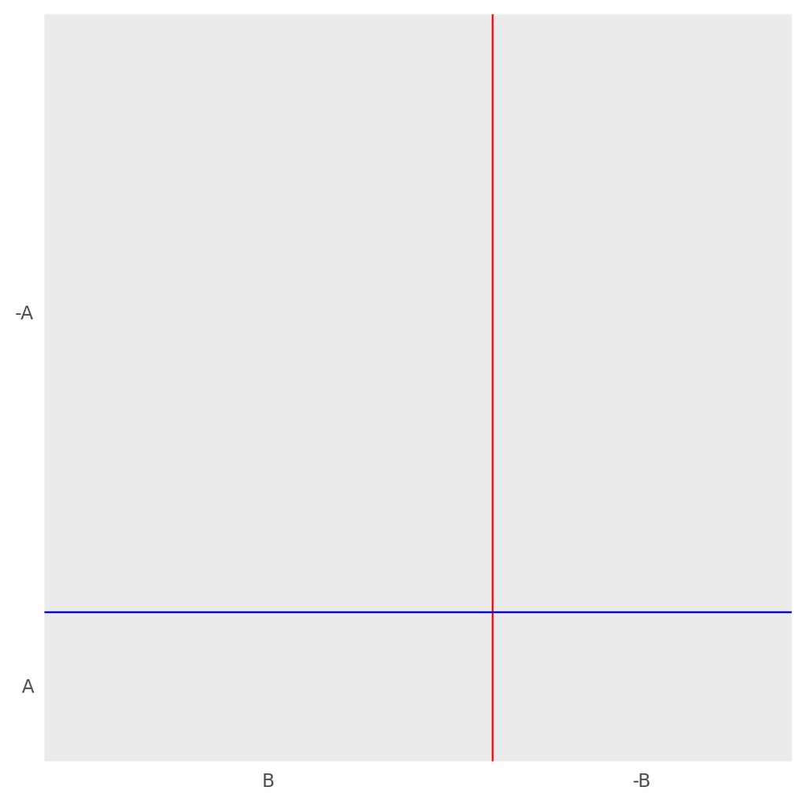

```python
mydraw(pn.ggplot(pd.DataFrame())
  + pn.scale_y_continuous(breaks=[0.1, 0.6], labels=["A", "-A"], limits = (0, 1), expand=(0, 0))
  + pn.scale_x_continuous(breaks=[0.3, 0.8], labels=["B", "-B"], limits = (0, 1), expand=(0, 0))
  + pn.geom_vline(pn.aes(xintercept=0.6), color='red')
  + pn.geom_hline(pn.aes(yintercept=0.2), color='blue')
  + pn.coord_equal()
  + pn.theme(panel_grid_major = pn.element_blank(),
             panel_grid_minor = pn.element_blank(),
             axis_title = pn.element_blank(),
         axis_ticks = pn.element_blank())
)
```

We have $\Pr[A] = 0.2$ and $\Pr[B] = 0.6.$ We can work out that
$$\Pr[A \mid B] = \frac{\Pr[A, B]}{\Pr[B]} = \frac{0.12}{0.6} = 0.2 = \Pr[A],$$
and
$$\Pr[B \mid A] = \frac{\Pr[B, A]}{\Pr[A]} = .\frac{0.12}{0.2} = 0.6 = \Pr[B].$$
Thus the events $A$ and $B$ are independent. We can also reason geometrically, noting that the ratio of $A$’s area to the total space’s area is the same as the ratio of $A \cap B$’s area to the area of $B.$ Now consider the following manner of partitioning the sample space.

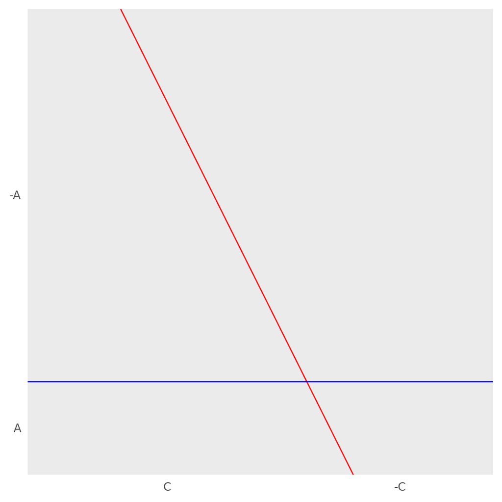

```python
mydraw(pn.ggplot(pd.DataFrame())
  + pn.scale_x_continuous(breaks=[0.3, 0.8], labels=["C", "-C"], limits = (0, 1), expand=(0, 0))
  + pn.scale_y_continuous(breaks=[0.1, 0.6], labels=["A", "-A"], limits = (0, 1), expand=(0, 0))
  + pn.geom_segment(pn.aes(x=0.2, y=1, xend=0.7, yend=0), color='red')
  + pn.coord_equal()
  + pn.geom_hline(pn.aes(yintercept=0.2), color='blue')
  + pn.theme(panel_grid_major = pn.element_blank(),
             panel_grid_minor = pn.element_blank(),
         axis_title = pn.element_blank(),
         axis_ticks = pn.element_blank())
)
```

Geometric reasoning here shows that $\Pr[A \mid C^\complement] < \Pr[A \mid C]$ and thus $A$ and $C$ are not independent.

### Conditional independence

A pair of events $A$ and $B$ are said to be *conditionally independent* given an event $C$ with $\Pr[C] > 0$ if
$$\Pr[A, B \mid C] = \Pr[A \mid C] \cdot \Pr[B \mid C].$$
As with independence, if $A$ and $B$ are conditionally independent given $C$, then $A$ doesn’t provide any information about the occurrence of $B$ if $C$ occurs,
$$\Pr[A \mid B, C] = \Pr[A \mid C]
\qquad \qquad
\Pr[B \mid A, C] = \Pr[B \mid C].$$

### Mutual independence

A sequence of events $A_0, A_1, \ldots, A_N$ is said to be *mutually independent* if

- $\Pr\!\left[\bigcap_{n = 1}^N A_n\right] = \prod_{n=1}^N \Pr[A_n],$ and
- every proper subsequence $A_m, A_{m+1}, \ldots, A_{M}$ is mutually independent, where a proper subsequence is one in which $m \neq 0$ or $M \neq N$ (i.e., it is not the whole sequence).

Conditional mutual independence is defined the same way.

## A.4 Random variables

In this section we introduce univariate and multivariate random variables and show how to define new random variables as functions of random variables.

### Random variables

Given a probability space $(\Omega, \mathcal{S}, \Pr)$, a *random variable* over this space is a function $X:\Omega \rightarrow \mathbb{R}$ such that for every $x \in \mathbb{R}$, the set $\{ \omega : X(\omega) \leq x \} \in \mathcal{S}$ (i.e., it is is measurable). A random variable is a deterministic function, and as such is neither a variable nor random by itself. The name derives because we often use simple variables like $X$ to refer to random variables in notation and because it derives its random structure from the underlying probability measure $\Pr,$ as we show in the rest of this section.

Given a random variable $X$, we define its range as usual for a function,
$$\textrm{range}(X) = \{ X(\omega) : \omega \in \Omega \}.$$
Because $X(\omega) \in \mathbb{R}$, the range is always a subset of real numbers. It is conventional to overload the membership operator for random variables and write $X \in A$ if $X(\omega) \in A$ for every $\omega \in \Omega.$

*Example 1, cont.* Our first example has a finite sample space, $\Omega = \{ 0, 1 \}.$ Over this sample space, we can define a random variable $X:\Omega \rightarrow \mathbb{R}$ by $X(0) = -2$ and $X(1) = 10$. This has $\textrm{range}(X) = \{ -2, 10 \}$ and represents the payoff of a 2 unit bet placed on the outcome $X = 1$ at 5:1 odds.

*Example 2(a), cont.* In this ongoing example, we have $\Omega = (0, 1)$. Because $\Omega \subseteq \mathbb{R}$, we can define a random variable $X$ by the identity function,
$$X(\omega) = \omega,$$
with a range equal to the sample space, $\textrm{range}(X) = (0, 1) = \Omega.$ The range of a random variable is not constrained by $\Omega$. Consider the random variable $Y$ over $\Omega = (0, 1)$ defined by
$$Y(\omega) = \textrm{logit}(\omega) = \log \frac{\omega}{1 - \omega},$$
which has $\textrm{range}(Y) = \mathbb{R}$. A third example is the random variable $Z$ defined by $Z(\omega) = \log \omega$, which has $\textrm{range}(Z) = (-\infty, 0)$. We can even have a random variable $T$ over $\Omega = (0, 1)$ with a discrete range by defining
$$T(\omega)
= \begin{cases}
1 & \textrm{if } \omega < 0.3, \textrm{ and}
\\
0 & \textrm{if } \omega \geq 0.3,
\end{cases}$$
so that $\textrm{range}(T) = \{ 0, 1 \}.$

*Example 2(b), cont.* We previously defined a probability space over the sample space $\Omega = \mathbb{R}$. We can define a random variable $U$ over $\Omega$ by the identity function,
$$U(\omega) = \omega,$$
which gives us $\textrm{range}(U) = \mathbb{R}.$ We can define a second random variable $V$ by
$$V(\omega) = \textrm{logit}^{-1}(\omega) = \frac{1}{1 + \exp(-\omega)},$$
which has $\textrm{range}(V) = (0, 1)$. A third example is $W$ defined by $W(\omega) = \omega^2$, which has $\textrm{range}(W) = [0, \infty)$.

### Independence for random variables

Two random variables $X$ and $Y$ are said to be *independent* if the events picked out by $X \leq x$ and $Y \leq y$ (i.e., $\{ \omega \in \Omega : X(\omega) \leq x \}$) are independent for all $x$ and $y.$

### Functions of random variables

Random variables partly derive their name because we can use them in arithmetic operations and as arguments to functions to produce new random variables. Given a random variable $X$ defined over a sample space $\Omega$ and a function a function $f:\textrm{range}(X) \rightarrow \mathbb{R}$, we can define a new random variable $Y$ over the same sample space by setting
$$Y(\omega) = f(X(\omega)).$$
This new random variable is conventionally written as $Y = f(X),$ which is yet another overload of conventional set-theory notation.

Functions of more than one random variable work the same way. If $X_1, \ldots, X_N$ are random variables and $f:\textrm{range}(X_1) \times \cdots \times \textrm{range}(X_N) \rightarrow \mathbb{R}$, then we write $Y = f(X_1, \ldots, X_N)$ for the random variable defined by
$$Y(\omega) = f(X_1(\omega), \ldots, X_N(\omega)).$$

*Example 2(a), cont.* Although we have given the random variables $X,$ $Y,$ and $T$ direct definitions, note that $Y = \textrm{logit}(X),$ $Z = \textrm{log}(X),$ and $T = \textrm{I}(X < 0.3).$

*Example 2(b), cont.* In this example, we have defined $U,$ $V,$ and $W$ as primitive random variables, but we also have $V = \textrm{logit}^{-1}(U)$ and $W = \textrm{U}^2.$

## A.5 Cdfs, pdfs, and pmfs

In this section, we introduce cumulative distribution functions (cdfs), probability density functions (pdfs), and probability mass functions (pmfs).

### Cumulative distribution function

Given a random variable $X$ defined over a probability space $(\Omega, \mathcal{S}, \Pr),$ its *cumulative distribution function* (cdf) $F_X:\mathbb{R} \rightarrow [0, 1]$ is defined for $x \in \mathbb{R}$ by
$$F_X(x) = \Pr[X \leq x],$$
where we read $X \leq x$ as the event $\{ \omega \in \Omega : X(\omega) \leq x \}$. The cdf of a random variable is well-defined because all of the relevant events $X \leq x$ must be measurable in order for $X$ to be a random variable.

The cdf $F_X$ of any random variable $X$ satisfies three important properties,

- $F_X$ is continuous from the right,
- $F_X$ is monotonic increasing (but not necessarily strictly so), and
- the limit as the argument goes to infinity is one,
  $$\lim_{x \rightarrow \infty} F_X(x) = 1.$$

*Example 1, cont.*: Continuing our minimal discrete example with $\Omega = \{ 0, 1 \}$, $\Pr[\{ 0 \}] = 0.3,$ and $\Pr[\{ 1 \}] = 0.7,$ consider a random variable that takes $X(0) = -2$ and $X(1) = 10$. The resulting cdf is
$$F_X(x) =
\begin{cases}
0 & \textrm{if } x \in (-\infty, 2),
\\
0.3 & \textrm{if } x \in [-2, 10), \textrm{ and}
\\
1.0 & \textrm{if } x \in [10, \infty).
\end{cases}$$

*Example 2(a), cont.* Taking up our example of $\Omega = (0, 1),$ with $\Pr[(a, b)] = b - a$ for $(a, b) \subseteq (0, 1),$ we see that the random variable $X(\omega) = \omega$ has the cdf $F_X:\mathbb{R} \rightarrow [0, 1]$ defined by
$$F_X(x)
= \begin{cases}
0 & \textrm{if } x \in (-\infty, 0),
\\
x & \textrm{if } x \in [0, 1), \textrm{ and}
\\
1 & \textrm{if } x \in [1, \infty).
\end{cases}$$
The result for $x \in [0, 1)$ follows because $F_X(x) = \Pr[X \leq x] = \Pr[(0, x)] = x.$

For the case of $Y(\omega) = \textrm{logit}(\omega),$ we have the cdf $F_Y:\mathbb{R} \rightarrow [0, 1]$ defined by
$$\begin{align}
F_Y(y) &= \Pr[Y \leq y]
\\[4pt]
&= \Pr[\textrm{logit}^{-1}(Y) \leq \textrm{logit}^{-1}(y)]
\\[4pt]
&= \Pr[X \leq \textrm{logit}^{-1}(y)]
\\[4pt]
&= \textrm{logit}^{-1}(y).
\end{align}$$

*Example 2(b), cont.* In this example, $\Omega = \mathbb{R}$ and $\Pr[(a, b)] = \textrm{logit}^{-1}(b) - \textrm{logit}^{-1}(a).$ Let the random variable $U$ be the identity i.e., $U(\omega) = \omega.$ The cdf of $U$ is the function $F_U:\mathbb{R} \rightarrow [0, 1]$ defined by
$$\begin{align}
F_U(u) &= \Pr[U \leq u]
\\[3pt]
&= \lim_{x \rightarrow -\infty} \, \Pr[U \in (x, u)]
\\[3pt]
&= \lim_{x \rightarrow -\infty} \, \textrm{logit}^{-1}(u) -
\textrm{logit}^{-1}(x)
\\[3pt]
&= \textrm{logit}^{-1}(u) - \lim_{x \rightarrow -\infty} \, \textrm{logit}^{-1}(x)
\\[3pt]
&= \textrm{logit}^{-1}(u).
\end{align}$$
This is the same cumulative distribution function as we had for $Y$ in Example 2(a). Consider a second random variable $V = \textrm{logit}^{-1}(U)$. The cdf of $V$ is given by
$$F_V(v)
= \begin{cases}
0 & \textrm{if } v \in (-\infty, 0)
\\
v & \textrm{if } v \in [0, 1)
\\
1 & \textrm{if } v \in [1, \infty).
\end{cases}$$
The middle case follows because
$$\begin{align}
F_V(v)
&= \Pr[V \leq v]
\\[4pt]
&= \Pr[\textrm{logit}(V) \leq \textrm{logit}(v)]
\\[4pt]
&= \Pr[U \leq \textrm{logit}(v)]
\\[4pt]
&= \textrm{logit}^{-1}(\textrm{logit}(v))
\\[3pt]
&= v.
\end{align}$$
Thus we see that $F_V$ in this example has the same cumulative distribution as $F_X$ in example 2(a).

### Probability density function

If the cumulative distribution function $F_X$ for a random variable $X$ is continuous and differentiable, we define its *probability density function* (pdf) $p_X:\mathbb{R} \rightarrow (0, \infty)$ by
$$p_X(x) = F_X'(x),$$
for $x \in \mathbb{R},$ where $F_X'$ is the derivative of the cdf. Thus the unit of measure for the cdf is probability, whereas the unit of measure for the pdf is change in probability.

Even though the cdf forms the theoretical foundation for distributions, in practice we usually work with pdfs and occasionally want to go back to the cdf, which we can do by integration,
$$F_X(x) = \int_{-\infty}^x \, p_X(x) \, \textrm{d}x.$$

We know that $\Pr[\Omega] = 1$ and that for any random variable $X,$ $\Pr[\Omega] = \lim_{x \rightarrow \infty} \, F_X(x) = 1$. Furthermore, we know $F_X(x) = \int_{-\infty}^x p_X(x) \textrm{d}x.$ Putting this together we have

$$\begin{align}
\int_{-\infty}^\infty p_X(x) \textrm{d}x
&= \lim_{x \rightarrow \infty} \int_{-\infty}^x p_X(x) \textrm{d}x
\\[4pt]
&= \lim_{x \rightarrow \infty} F_X(x)
\\[4pt]
&= 1.
\end{align}$$

*Example 2(a), cont.* We have a random variable $X$ with cdf $F_X(x) = x,$ for $x \in X,$ so the pdf is
$$p_X(x) = F_X'(x) = \frac{\textrm{d}}{\textrm{d}x} x = 1.$$
A constant density indicates the variable has a *uniform distribution.* The uniform distribution has an associated function for $\alpha < \beta \in \mathbb{R},$
$$\textrm{uniform}(x \mid \alpha, \beta) = \frac{1}{\beta - \alpha}.$$
If a random variable $X$ has a density $p_X(x) = \textrm{uniform}(x \mid \alpha, \beta),$ we write
$$X \sim \textrm{uniform}(\alpha, \beta).$$
In this notation, $\alpha$ and $\beta$ might themselves be random variables, which require the notion of conditional density, which we define below.

For our second random variable $Y$, the cdf is $F_Y(y) = \textrm{logit}^{-1}(y),$ and so the pdf is
$$p_Y(y) = F_Y'(y) = \frac{\textrm{d}}{\textrm{d}y} \textrm{logit}^{-1}(y) =
\textrm{logit}^{-1}(y) \cdot (1 - \textrm{logit}^{-1}(y)).$$
Variable $Y$ has a standard *logistic distribution*, and we write
$$Y \sim \textrm{logistic}(0, 1).$$
The general definition of the logistic distribution’s density involves parameters $\mu \in \mathbb{R}$ and $\sigma \in (0, \infty),$
$$\textrm{logistic}(y \mid \mu, \sigma)
= \textrm{logit}^{-1}\!\left(\frac{y - \mu}{\sigma}\right)
\cdot
\left(1 - \textrm{logit}^{-1}\!\left(\frac{y - \mu}{\sigma}\right)\right).$$
The use of $\mu$ and $\sigma$ in this configuration defines what’s known as a *location-scale parameterization.* The *standard parameterization* takes the location to be zero and the scale to be one. If $Y \sim \textrm{logistic}(0, 1)$ (i.e., it has a standard logistic distribution), then $Z = \mu + \sigma \cdot Y$ is such that $Z \sim \textrm{logistic}(\mu, \sigma).$ The parameter $\sigma$ used to scale is called a *scale parametrer* and the parameter $\mu$ used to translate or shift is called a *location parameter*.

The following code and plot shows the cdf and pdf for the standard logistic distribution.

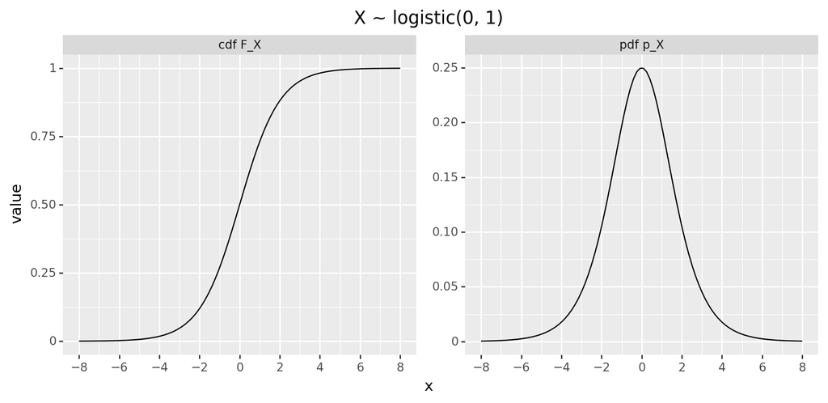

```python
def logit(x):
    return np.log(x / (1 - x))
def inv_logit(x):
    return 1 / (1 + np.exp(-x))

x = np.linspace(-8, 8, 100)
pdf_y = [inv_logit(x_n) * (1 - inv_logit(x_n)) for x_n in x]
df_pdf = pd.DataFrame({
    'x': x, 'y': pdf_y, 'type': 'pdf p_X'
})
cdf_y = [inv_logit(x_n) for x_n in x]
df_cdf = pd.DataFrame({
    'x': x, 'y': cdf_y, 'type': 'cdf F_X'
})
df = pd.concat([df_pdf, df_cdf])
mydraw(pn.ggplot(df, pn.aes(x='x', y='y')) + pn.geom_line()
    + pn.facet_wrap('~ type', scales = 'free_y')
    + pn.labs(x='x', y='value', title = 'X ~ logistic(0, 1)')
    + pn.scale_x_continuous(breaks = [-8, -6, -4, -2, 0, 2, 4, 6, 8])
    + pn.theme(figure_size=(10, 4), panel_spacing=0.5))
```

The side-by-side plots illustrate how the pdf $p_X$ is the derivative of the cdf $F_X.$ The derivative of the cdf, and hence the pdf, is maximized at $X = 0,$ and approaches zero as $X \rightarrow \infty$ or $X \rightarrow -\infty.$ The chain rule for derivatives cancels the outer negation and establishes symmetry,
$$F_X(x) = 1 - F_X(-x)
\qquad \qquad
F_X'(x) = F_X'(-x)
\qquad \qquad
p_X(x) = p_X(-x).$$

#### Change of variables (univariate)

Suppose I have a univariate random variable $X:\Omega \rightarrow \mathbb{R}$ and a function $f:\mathbb{R} \rightarrow \mathbb{R}$. Then I can define a new random variable $Y = f(X)$ by defining
$$Y(\omega) = f(X(\omega))$$
for a point $\omega \in \Omega$ in the sample space.

If the function $f$ is a differentiable, monotonic (up or down), and one-to-one, then the standard *change of variables* formula for densities applies, so that the density function for $Y$ is
$$p_Y(y) = p_X(f^{-1}(y)) \cdot (f^{-1})'(y),$$
where $f^{-1}$ is the inverse of $f$ and $(f^{-1})'$ is the derivative of the inverse of $f$. We consider multivariate changes of variables when we introduce vector-based random variables below.

### Probability mass function

If the cumulative distribution function $F_X$ for a random variable $X$ is discrete (in the sense of being made up only of step functions), then we define its *probability mass function* (pmf) $p_X:\mathbb{N} \rightarrow (0, \infty)$ by
$$p_X(n) = \Pr[X \leq n + 1] - \Pr[X \leq n] = F_X(n + 1) - F_X(n),$$
for $n \in \mathbb{N}$.

The *support* of a random variable $X$ is the set of values it can take on, which is formally defined as the values for which the pdf or pmf is strictly greater than 0,
$$\textrm{supp}(X) = \{ x : p_X(x) > 0 \}.$$

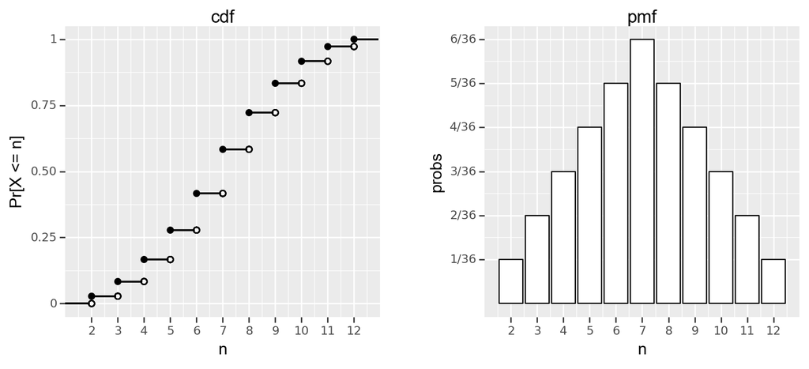

```python
support = np.arange(2, 13)
probs = [0, 1/36, 2/36, 3/36, 4/36, 5/36, 6/36, 5/36, 4/36, 3/36, 2/36, 1/36]
cdf_values = np.cumsum(probs)
df = pd.DataFrame({
    'n': support,  'cdf': cdf_values[1:12], 'cdf_low': cdf_values[0:11],
})
plot1 = (pn.ggplot(df, pn.aes(x='n', y='cdf'))
    + pn.geom_point(size=2)
    + pn.scale_x_continuous(breaks=np.arange(2, 13))
    + pn.labs(x='n', y='Pr[X <= n]')
    + pn.scale_x_continuous(limits=(1,13),
                            breaks=support, expand=(0, 0))
    + pn.ggtitle('cdf')
    + pn.theme(strip_margin_x=5.0))
for n in range(0,12):
    plot1 += pn.geom_segment(pn.aes(x = n + 1,
               y = cdf_values[n], xend = n + 2 - 0.075,
               yend = cdf_values[n]))
    plot1 += pn.geom_point(pn.aes(x='n', y='cdf_low'),
               size=2, stroke=0.5, fill='none',
           shape='o', color='black')
df2 = pd.DataFrame({ 'n': support, 'probs': probs[1:] })
plot2 = (pn.ggplot(df2, pn.aes(x='n', y='probs'))
         + pn.geom_bar(stat='identity', color='black', fill='white')
         + pn.scale_x_continuous(breaks=support)
         + pn.scale_y_continuous(breaks=np.arange(1, 7) / 36,
               labels=['1/36', '2/36', '3/36', '4/36', '5/36', '6/36'])
         + pn.ggtitle('pmf'))
g12 = (pw.load_ggplot(plot1, figsize=(3.25, 3))
      | pw.load_ggplot(plot2, figsize=(3.25, 3)))
g12.savefig()
```

The characterization of random variables with pdfs and pmfs is incomplete because not all probability distributions can be classified as discrete or continuous. A random variable $X$ can have a cdf with both continuous portions and jumps. For example, if we define a mixture of a discrete and continuous cdf (e.g., for a spike-and-slab prior in Bayesian statistics), we get a cdf that is neither discrete nor continuous (we provide an example and plot its cdf below).

### Conditional cdfs, pdfs, and pmfs

#### Conditional cumulative distribution function

If $X:\Omega \rightarrow \mathbb{R}$ is a random variable and $A \subseteq \Omega$ is an event with $\Pr[A] > 0,$ the *conditional cumulative distribution function* is
$$F_{X \mid A}(x) = \Pr[X \leq x \mid A],$$
where we read $X \leq x$ as the event $\{ \omega \in \Omega : X(\omega) \leq x \}.$

#### Conditional probability mass functions

If $X$ is a discrete random variable, the *conditional probability mass function* is
$$p_{X \mid A}(x) = \Pr[X = x \mid A],$$
where $X = x$ picks out the event $\{ \omega \in \Omega : X(\omega) = x \}.$

Suppose $Y:\Omega \rightarrow \mathbb{R}$ is a discrete random variable (i.e., $\textrm{range}(Y)$ is countable). It is conventional to further overload notation and terminology and define the *conditional probability mass function* $p_{X \mid Y}$ by taking
$$p_{X \mid Y}(x \mid y)
= \Pr[X = x \mid Y = y].$$
It follows that
$$p_{X \mid Y}(x, y) = \frac{p_{X, Y}(x, y)}{p_Y(y)}.$$

#### Conditional probability density functions

If $X$ is continuous, the *conditional probability density function* is defined by differentiation,
$$p_{X \mid A}(x) = F_{X \mid A}'(x).$$

If $Y$ is also continuous, we will define a limit that provides the conditional form. Let $Y^{y, \epsilon}$ be the event determined by the condition $Y \in (y - |\epsilon|, y + |\epsilon|)$ and define
$$p_{X \mid Y}(x \mid y)
= \lim_{\epsilon \rightarrow 0} \ p_{X \mid Y^{\mbox{$\scriptstyle y,\epsilon$}}}(x).$$
It follows that
$$p_{X \mid Y}(x \mid y) = \frac{p_{X, Y}(x, y)}{p_Y(y)}.$$

#### Conditioning on discrete and continuous variables

In practice, we might have a variable (discrete or continuous) whose value depends on the value of one or more discrete variables and one or more continuous variables (e.g., the outcome of a drug trial based on a patient’s discrete age group and continuous blood pressure). In this case, we define the cdf by conditioning on equality for discrete variables and by taking limits of surrounding intervals (balls in higher dimensions) for continuous variables. If the resulting variable is discrete, its pmf is defined by differences of the cdf; if it is continuous, the pdf is defined by differentiating the cdf.

In all cases, we will rely on the fact that for any random variables $X$ and $Y$, including multivariate ones, we have
$$p_{X \mid Y}(x \mid y) = \frac{p_{X, Y}(x, y)}{p_Y(y)}.$$
Here, we have exploited the overloaded $p$ notation, which allows for discrete, continuous, or mixed random variables.

*Example 5.* Suppose we have a continuous random variable $Y$ that depends on a discrete random variable $U$ and a continuous random variable $V.$ Then we define the conditional density as a partial derivative of a limit conditioned on the discrete outcome,
$$p_{Y \mid U, V}(y \mid u, v) =
\frac{\partial}{\partial y}
\lim_{\epsilon \rightarrow 0}
F_{Y \mid U = u, \ V \in (v - |\epsilon|, v+ |\epsilon|)}(y).$$

### Mixed continuous and discrete variables

Not all random variables can be classified as continuous or discrete—some have cumulative distribution functions that are continuous in some segments and step functions elsewhere. In our applied examples, such distributions will be constructed from simpler continuous and discrete distributions.

*Example 6.* Suppose we have a binary random variable $Z$ (i.e., $\textrm{range}(Z) = \{ 0, 1 \}$) and a continuous random variable $U$ with $\textrm{range}(U) = \mathbb{R}.$ We can define a new random variable $Y$ by
$$Y =
\begin{cases}
0 & \textrm{if } Z = 1, \textrm{ and}
\\[2pt]
U & \textrm{if } Z = 0.
\end{cases}$$
The variable $Y$ will have $\textrm{range}(Y) = \mathbb{R},$ so it is not technically discrete. Nevertheless, we see that $\Pr[Y = 0] = \Pr[Z = 1],$ which cannot happen in a continuous distribution (where all points have zero probability). The cdf $F_Y$ is equal to the cdf $F_U$ scaled by the probability $Z = 0$, with a jump at zero of $\Pr[Z = 1],$
$$F_Y(y) =
\begin{cases}
F_U(y) \cdot \Pr[Z = 0] & \textrm{if } y < 0, \textrm{ and}
\\[4pt]
\Pr[Z = 1] + F_U(y) \cdot \Pr[Z = 0] & \textrm{if } y > 0.
\end{cases}$$
Zero-inflated continuous distributions are sometimes called *spike and slab* distributions, because the probability mass at zero acts as a “spike” (i.e., as a delta function for integration), with the underlying continuous distribution forming the “slab” (especially in when there is a high probability of extreme values).

Here is a plot of the resulting mixed cdf for the case $\Pr[Z = 1] = 0.4$, with the standard logistic distribution as the continuous component (i.e., with cdf $\textrm{logit}^{-1}.)$

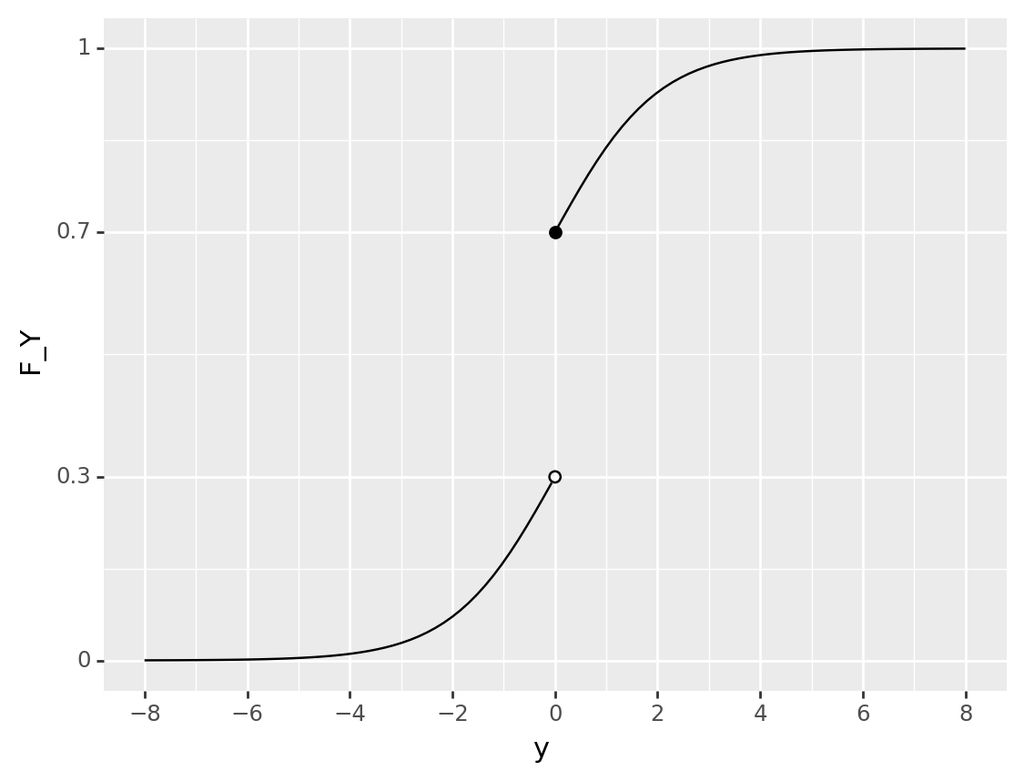

```python
p = 0.4
def mix_cdf(y):
    cdf_y = (1 - p) * inv_logit(y)
    return cdf_y if y < 0 else cdf_y + p
y_left = np.linspace(-8, -0.065, 50)
y_right = np.linspace(0, 8, 50)
F_Y_left = [mix_cdf(y_n) for y_n in y_left]
F_Y_right = [mix_cdf(y_n) for y_n in y_right]
df_left = pd.DataFrame({ 'y': y_left, 'F_Y': F_Y_left })
df_right = pd.DataFrame({ 'y': y_right, 'F_Y': F_Y_right })
mydraw(pn.ggplot(pn.aes(x = 'y', y = 'F_Y'))
    + pn.geom_line(data = df_left)
    + pn.geom_line(data = df_right)
    + pn.geom_point(data = pd.DataFrame({'x': [0], 'y': [(1 - p) / 2]}),
                    mapping = pn.aes(x = 'x', y = 'y'), size=2,
            shape='o', stroke = 0.5, fill='none')
    + pn.geom_point(data = pd.DataFrame({'x': [0], 'y': [1 - (1 - p) / 2]}),
                    mapping = pn.aes(x = 'x', y = 'y'), size=2)
    + pn.scale_x_continuous(breaks = np.linspace(-8, 8, 9))
    + pn.scale_y_continuous(breaks = [0, 0.3, 0.7, 1])
)
```

## A.6 Multivariate random variables

Although we have only described univariate random variables that take values in $\mathbb{R}$, if we take a collection of random variables $X_1, \ldots, X_N$ we can combine them into a multivariate random variable $X:\Omega \rightarrow \mathbb{R}^N$, by taking
$$X(\omega) = [X_1(\omega) \ \cdots \ X_N(\omega)].$$
In this case, we can write $X = [X_1 \ \cdots \ X_N].$ The same construction may be naturally extended to matrices, tensors, etc.

*Example 4.* Consider a sample space $(0, 1)^2$ with a Borel $\sigma$-algebra and probability function given by area (i.e., the Lebesgue measure), so that if $A \subseteq (0,1)^2,$ we have $\Pr[A] = \int_{(0,1)^2} \, \textrm{I}(x \in A) \, \textrm{d}x.$ We can define a random variable $X$ by $X(\omega) = \pi_1(\omega),$ where $\pi_1$ is the *projection function* defined by $\pi_1\!\left((x,y)\strut\right) = x,$ and a second random variable $Y$ defined by $Y(\omega) = \pi_2(\omega),$ where $\pi_2\!\left((x, y)\strut\right) = y.$ We can define a multivariate random variable $Z = [X \quad Y],$ which could have also been defined directly by $Z(\omega) = \omega.$

### Functions of multivariate random variables

As in the univariate case, we can directly apply real-valued multivariate functions to a sequence of random variables to define new random variables. For example, if $f:\textrm{range}(X_1) \times \cdots \times \textrm{range}(X_N) \rightarrow \mathbb{R}^M,$ then we get a new random variable $Y = f(X)$ defined by
$$Y(\omega) = f(X_1(\omega), \ldots, X_N(\omega)).$$

*Example 4, cont.* We can take the random variables $X$ and $Y$ and define a new random variable $L = \sqrt{X^2 + Y^2}$ which is the Euclidean distance from the origin to the point $(X, Y)$. We can move back and forth between univariate and multivariate functions. For example, we could have defined $L$ as a function of the multivariate variable $Z$ by $L = \sqrt{Z_1^2 + Z_2^2}.$

### Change of variables (multivariate)

Suppose we have a random variable $X \in \mathbb{R}^N$ and a smooth, invertible function $f:\mathbb{R}^N \rightarrow \mathbb{R}^N.$ Then we define $Y = f(X)$ to be a new random variable, and note that its density is
$$p_Y(y)
= p_X\!\left(f^{-1}(y)\right)
\cdot \left| \nabla \! \left( f^{-1} \right) \! \left(y\right) \right|,$$
where $\nabla g$ is read as the Jacobian of the function $g$ and $\left| A \right|$ is read as the absolute determinant of the matrix $A.$ Here the function $g = f^{-1}$ maps $\mathbb{R}^N$ to $\mathbb{R}^N,$ so $\nabla\!\left(f^{-1}\right)$ is an $N \times N$ matrix.

### Multivariate cdfs, pmfs, and pdfs

The *cumulative distribution function* for a multivariate random variable $X:\Omega \rightarrow \mathbb{R}^N$ is defined by
$$F_X(x_1, \ldots, x_N)
= \Pr[x_1 \leq X_1, \cdots, x_N \leq X_N]
= \Pr[\{ x \in \mathbb{R}^N : x_1 \leq X_1, \ldots, x_N \leq X_N \}].$$

The *probability mass function* for a discrete multivariate random variable is
$$p_X(x_1, \ldots, x_N)
= \Pr[X_1 = x_1, \ldots, X_N = x_n].$$

The *probability density function* for a continuous multivariate random variable $X \in \mathbb{R}^N$ is defined as the function $p_X:\mathbb{R}^N \rightarrow [0, \infty)$ that has the property that for any event $A \in \mathcal{S},$
$$\Pr[x \in A] = \int_A p_X(x) \textrm{d} x,$$
or in terms of rectangular integrations and the cdf,
$$F_X(x) = \int_0^{x_1} \cdots \int_0^{x_N} p_X([x_1 \quad
\cdots \quad x_N]) \, \textrm{d}x_N \cdots \textrm{d}x_1.$$

We can marginalize a joint cdf with a limit,
$$F_X(x) = \lim_{y \rightarrow \infty} F_{X, Y}(x, y).$$
The *law of total probability* holds for joint densities,
$$p_X(x) = \int_{\mathbb R} \, p_{X, Y}(x, y) \, \textrm{d}y.$$

Conditional cdfs, pmfs, and pdfs are defined in the same way as for univariate random variables. This leads to a common form of marginalization where the joint density is factored,
$$p_X(x) = \int_{\mathbb R} \, p_{X \mid Y}(x \mid y) \cdot p_Y(y) \, \textrm{d}y.$$

## A.7 Expectations

### Expectation

If we have a (potentially multivariate) random variable $Z$, we write $\mathbb{E}[Z]$ for its *expectation*, which despite the fancy name, is just its average value, weighted by its density,
$$\mathbb{E}[Z] = \int_{\textrm{supp}(Z)} z \cdot p_Z(z) \, \textrm{d}z.$$
Discussing random variables presupposes a background probability space $(\Omega, \mathcal{S}, \Pr)$ with respect to which the cumulative distribution function $F_Z$ and the probability density function $p_Z$ are defined.

Statistical notation overloads many notations, and commonly just $Z$ rather than $\textrm{supp}(Z)$ is used to subscript the integral.

Expectations are linear operators in that if $a, b$ are constants and $X$ is a random variable, then
$$\mathbb{E}[a + b \cdot X] = a = b \cdot \mathbb{E}[X].$$
Expectations are also additive in random variables,
$$\mathbb{E}[X + Y] = \mathbb{E}[X] = \mathbb{E}[Y].$$
If $X$ and $Y$ are independent, then we also have
$$\mathbb{E}[X \cdot Y] = \mathbb{E}[X] \cdot \mathbb{E}[Y].$$

### Conditional expectation

With Bayesian statistics, we are typically interested in conditional expectations, which are the value of a random variable conditioned on the observed value of a second random variable. Suppose $Y$ is a second random variable over the same implicit probability space and we observe that $Y = y$. The *conditional expectation* of $Z$ given $Y = y$ is
$$\mathbb{E}[Z \mid Y = y]
= \int_{Z} z \cdot p_{Z \mid Y}(z \mid y) \, \textrm{d}z.$$
That is, we take a weighted average of the value of $Z$ with weights determined by the conditional density $p_{Z \mid Y}(z \mid y)$.

### Expectations of functions of random variables

Suppose we have a random variable $Z$ and a real-valued function $f:\textrm{supp}(Z) \rightarrow \mathbb{R}^N$. We can then define a new random variable $W = f(Z)$. To calculate the expectation of $W$ in terms of the density for $Z$, we use the so-called *law of the unconscious statistician*, which tells us we can simplify the change of variables back to a direct average over $Z$,
$$\begin{align}
\mathbb{E}[f(Z)]
&= \mathbb{E}[W]
\\[4pt]
&= \int_W w \cdot p_W(w) \, \textrm{d}w.
\\[4pt]
&= \int_W w \cdot p_Z(f^{-1}(w)) \cdot (f^{-1})'(w) \, \textrm{d}w.
\\[4pt]
&= \int_Z f(z) \cdot p_Z(z) \, \textrm{d}z,
\end{align}$$
where we have written $f^{-1}$ for the inverse transfrom form $W$ back to $Z$ and $(f^{-1})'$ for its derivative. The first line is the definition, the second is a standard univariate change of variables (see above), but deriving the third line in the general case requires measure-theoretic techniques beyond this short introduction.

The conditional form follows suit,
$$\mathbb{E}[f(Z) \mid Y = y] = \int_Z f(z) \cdot p_{Z \mid Y}(z \mid y) \, \textrm{d}z.$$
Either way, we just take a weighted average the value of $f(z)$ with weights $p_Z(z)$ or $p_{Z|Y}(z \mid y).$

## A.8 Variance, standard deviation, covariance, and correlation

### Variance

The *variance* of a random variable is the expectation of its squared difference from the expectation,
$$\textrm{var}[X]
= \mathbb{E}\!\left[
\left( X - \mathbb{E}[X] \right)^2
\right].$$
Variance can be decomposed as follows.
$$\begin{align}
\textrm{var}[X]
&= \mathbb{E}\!\left[
\left( X - \mathbb{E}[X] \right)^2
\right]
\\[4pt]
&= \mathbb{E}\!\left[ \,
X^2 - 2 \cdot X \cdot \mathbb{E}[X] + \mathbb{E}[X]^2
\, \right]
\\[4pt]
&= \mathbb{E}\!\left[X^2 \right]
- \mathbb{E}\!\left[2 \cdot X \cdot \mathbb{E}[X]\right]
+ \mathbb{E}\!\left[\mathbb{E}[X]^2\right]
\\[4pt]
&= \mathbb{E}\!\left[X^2 \right]
- 2 \cdot \mathbb{E}[X] \cdot \mathbb{E}[X]
+ \mathbb{E}[X]^2
\\[4pt]
&= \mathbb{E}\!\left[X^2\right] - \mathbb{E}[X]^2.
\end{align}$$

If $X$ represents a distance measured in meters, then the variance $\textrm{var}[X]$ is expressed in square meters. This can make it tricky to reason about variances.

Adding a constant $c \in \mathbb{R}$ to a random variable $X$ does not change its variance,
$$\textrm{var}[c + X] = \textrm{var}[X].$$
Multiplying the variance requires quadratic scaling,
$$\textrm{var}[c \cdot X] = c^2 \cdot \textrm{var}[X].$$
The variance of a sum is the sum of the variances,
$$\textrm{var}[U + V] = \textrm{var}[U] + \textrm{var}[V].$$

### Standard deviation

The *standard deviation* of a random variable is the square root of its variance,
$$\textrm{sd}[X] = \sqrt{\textrm{var}[X]}.$$
The units of the standard deviation are identical to those of the random variable $X$. Thus we say that the standard deviation is the *scale* of a variable’s variation.

Standard deviations of a random variable $X$ have the same scale as the random variable $X$ itself. They also drop additive constants, but unlike variances, they scale linearly with multiplication due to their scale. For any constant $c \in \mathbb{R},$ we have
$$\begin{align}
\textrm{sd}[c + X] &= \textrm{sd}[X]
\\[4pt]
\textrm{sd}[c \cdot X] &= c \cdot \textrm{sd}[X].
\end{align}$$
The standard deviation of a sum works through the fact that variances are additive,
$$\textrm{sd}[U + V]
= \sqrt{\textrm{sd}[U]^2 + \textrm{sd}[V]^2}.$$

### Covariance

If we have two random variables $X$ and $Y$, their *covariance* is defined as
$$\textrm{cov}[X, Y]
= \mathbb{E}\!\left[\strut (X - \mathbb{E}[X]) \cdot (Y - \mathbb{E}[Y])\right].$$
Covariance is measured in units that are the product of the units of $X$ and the units of $Y$. For example if $X$ is watts and $Y$ is hours, then the units of $\textrm{cov}[X, Y]$ is watt-hours. As an operation, covariance is commutative in that $\textrm{cov}[X,Y] = \textrm{cov}[Y, X].$

The covariance between a variable and itself is just its variance,
$$\textrm{cov}[X, X]
= \mathbb{E}\!\left[ \strut (X - \mathbb{E}[X])
\cdot (X - \mathbb{E}[X])\right]
= \mathbb{E}\!\left[ \strut (X - \mathbb{E}[X])^2\right]
= \textrm{var}[X].$$

*Example 6.* We can construct a pair of scalar random variables $(X, Y)$ that covary by generating data according to a simple linear regression with $\mathbb{E}[Y] = \alpha + \beta \cdot X,$
$$\begin{align}
p_X(x) &= \textrm{normal}(x \mid 0, \tau), \textrm{ and}
\\[4pt]
p_{Y \mid X}(y \mid x)
&= \textrm{normal}(y \mid \alpha + \beta \cdot x, \sigma),
\end{align}$$
where $\sigma, \tau \in (0, \infty)$ are scale parameters (i.e., determine the distribution’s standard deviation). Because the normal distribution uses a location-scale parameterization, we can also construct $Y$ using a simple change of variables using a new variable $E$ corresponding to the “error,”
$$\begin{align}
Y &= \alpha + \beta \cdot X + E
\\[4pt]
p_E(\epsilon) &= \textrm{normal}(0, \sigma).
\end{align}$$
We know from regression theory that if $Y = \alpha + \beta \cdot X + E$ where $E$ has a normal distribution, then
$$\beta = \frac{\textrm{cov}[X, Y]}{\textrm{var}[X]},$$
and hence
$$\textrm{cov}[X, Y] = \beta \cdot \textrm{var}[X] = \beta \cdot \tau^2.$$
We can validate our mathematical derivation via simulation.

```python
M = 100_000
tau = 2.3
sigma = 1.5
alpha, beta = 1.3, -0.7
x = np.random.normal(loc = 0, scale = tau, size = M)
y = np.random.normal(loc = alpha + beta * x, scale = sigma, size = M)
cov_hat = np.cov(x, y)[0, 1]
print(f"sample cov(x, y) = {cov_hat:5.2f}")
```

```
sample cov(x, y) = -3.70
```

Here, we expect the sample covariance to be very close to $\beta \cdot \tau^2 = -0.7 \cdot 2.3^2 = -3.703.$

### Correlation

The *correlation* between two random variables is their inverse scaled covariance,
$$\textrm{corr}[X, Y]
= \frac{\textrm{cov}[X, Y]}
{\textrm{sd}[X] \cdot \textrm{sd}[Y]}.$$
The units all cancel here—the numerator has units in the square of the original variables as does the denominator. Like covariance, correlation is commutative.

The correlation between a variable and itself is the unit,
$$\textrm{corr}[X, X]
= \frac{\textrm{var}[X]}
{\textrm{sd}[X] \cdot \textrm{sd}[X]}
= 1.$$

*Example 6, cont.* Given that we have computed the covariance between $X$ and $Y$, we can compute their correlation by dividing by their scales,
$$\textrm{corr}[X, Y]
= \frac{\textrm{cov}[X, Y]}{\textrm{sd}[X] \cdot \textrm{sd}[Y]}.$$
We know that $\textrm{sd}[X] = \tau,$ but $Y$ is a compound that inherits additional uncertainty form its location parameter being a random variable itself. Nevertheless, because $Y = \alpha + \epsilon + \beta \cdot X$, where $\alpha$ is constant and both $E$ and $X$ are normal, we just add variances of the varying terms and then take the square root to return to the standard deviation scale,
$$\textrm{sd}[Y] = \sqrt{\textrm{var}[\beta \cdot X] + \textrm{var}[E]}
= \sqrt{\beta^2 \cdot \textrm{var}[X] + \textrm{var}[E]}
= \sqrt{\beta^2 \cdot \tau^2 + \sigma^2}
\approx 2.200.$$
Therefore, the correlation will be
$$\textrm{corr}[X, Y]
= \frac{\textrm{cov}[X, Y]}{\textrm{sd}[X] \cdot \textrm{sd}[Y]}
= \frac{\beta \cdot \tau^2}{\sigma \cdot \sqrt{\beta^2 \cdot \tau^2 + \sigma^2}}
= \frac{-0.7 \cdot 2.3^2}{2.3 \cdot 2.2} \approx -0.732.$$
The simulation results agree with the mathematics.

```python
print(f"sd(x) = {np.std(x):5.2f};  sd(y) = {np.std(y):5.2f}")
corr_hat = np.corrcoef(x, y)[0, 1]
print(f"sample corr(x, y) = {corr_hat:5.2f}")
```

```
sd(x) =  2.30;  sd(y) =  2.20
sample corr(x, y) = -0.73
```

### Covariance and correlation matrices

If we have a random variable $X:\Omega \rightarrow \mathbb{R}^N$, its *covariance matrix* is
$$\textrm{cov}[X]
= \mathbb{E}\!\left[(X - \mathbb{E}[X]) \cdot (X - \mathbb{E}[X])^{\top}\right].$$
The covariance matrix of $X$ has entries that are covariances of its elements,
$$\textrm{cov}[X]_{i,j} = \textrm{cov}[X_i, X_j].$$
Covariance matrices are symmetric and positive definite (and hence full rank). The units of the entries are squared relative to the original variable $X$.

The *correlation matrix* for $X$ standardizes the covariance matrix by dividing by the scales,
$$\textrm{corr}[X] = S^{-1} \cdot \textrm{cov}[X] \cdot S^{-1},$$
where $S$ is the diagonal matrix of scales, $S_{n,n} = \textrm{sd}[X_n].$ The entries are the correlations between pairs of components,
$$\textrm{corr}[X]_{i,j}
= \frac{1}{\textrm{sd}[X_i]} \cdot \textrm{cov}[X_i, X_j] \cdot \frac{1}{\textrm{sd}[X_j]}
= \textrm{corr}[X_i, X_j].$$

## A.9 Quantiles, medians, and uncertainty intervals

The *quantile function* for a continuous random variable $Z$ is its inverse cdf, $F^{-1}_Z:(0, 1) \rightarrow \textrm{range}(Z).$ nFor a value $p \in (0, 1),$ we say that $F^{-1}_Z(p)$ is the *$p$-quantile* of $Z$. In terms of probabilities, if $z = F^{-1}_Z(p),$ then $\Pr[Z \leq z] = p.$

The 50% quantile, $F_Z^{-1}(0.5),$ is known as the *median*. There is a 50% chance that a random variable takes on a value less than its median and a 50% chance that it takes on a value greater.

We can define posterior intervals for variables using quantile functions. For a random variable $X$ and $p \in (0, 1)$ the *central $p$ posterior interval* of $X$ is $\left( F_X^{-1}\!\left(\frac{1 - p}{2}\right), F_X^{-1}\!\left(1 - \frac{1 - p}{2}\right) \right),$ and it has its nominal coverage by definition,
$$\Pr\!\left[X \in \left( F_X^{-1}\!\left(\frac{1 - p}{2}\right),
F_X^{-1}\!\left(1 - \frac{1 - p}{2}\right) \right)\right]
= p.$$